# 03 GDV Classification Schemes

Choropleth map classification scheme examples.

```r
library(sf)
library(classInt)
library(ggplot2)
```

## Create data frame from GeoPackage (GPKG)

```r
# Create an `sf` data frame from a GeoPackage (GPKG)
osogs_pop_est_lad_merged <- st_read('../../data/lad-os-open-greenspace-area-per-head.gpkg')
```

```r
# List names of attributes
names(osogs_pop_est_lad_merged)
```

```
[1] "lad21cd"         "lad21nm"         "area"            "population"      "area2population"
[6] "geom"
```

```r
# Return head of data frame
head(osogs_pop_est_lad_merged)
```

```
Simple feature collection with 6 features and 5 fields
Geometry type: MULTIPOLYGON
Dimension:     XY
Bounding box:  xmin: 515485.4 ymin: 156480.9 xmax: 554090.8 ymax: 198355.2
Projected CRS: OSGB 1936 / British National Grid
    lad21cd              lad21nm       area population area2population                           geom
1 E09000002 Barking and Dagenham  149368.39     218534       0.6835018 MULTIPOLYGON (((548881.8 19...
2 E09000003               Barnet 1896580.99     388639       4.8800583 MULTIPOLYGON (((524579.9 19...
3 E09000004               Bexley  842554.47     246543       3.4174747 MULTIPOLYGON (((547869.8 18...
4 E09000005                Brent 1267192.74     338918       3.7389361 MULTIPOLYGON (((520278.8 19...
5 E09000006              Bromley 2660504.39     329830       8.0662899 MULTIPOLYGON (((541212.7 17...
6 E09000007               Camden   27727.58     210390       0.1317914 MULTIPOLYGON (((527195.1 18...
```

## Data Classification

Categorising data into groups for plotting can be seen as a classification problem. The method chosen should take into account the goal of the map (e.g. highlighting outliers vs. depicting the distribution of values). To help decide on the breaks to use please see these helpful links [here](https://censusgis.wordpress.com/students/lesson-5-visualisation-cartographic-practice/) and [here](https://gisgeography.com/choropleth-maps-data-classification/).

The R package [`classInt`](https://r-spatial.github.io/classInt/index.html) which is used by `tmap`, can be used for choropleth map classification. Classification schemes can be used via the `style` keyword argument in `tm_*` calls.

The content below looks at four commonly used classification schemes:

1. Equal Interval
2. Jenks (Natural Breaks)
3. Quantiles
4. Standard Deviation

### Equal Interval

The boundaries between classes are at regular intervals. It is simple and easy to interpret. However, it considers the extreme values of the distribution and, in some cases, this can result in one or more classes being sparse.

```r
ei5 <- classIntervals(osogs_pop_est_lad_merged$area2population,
                      n = 5, style = 'equal')

ei5
```

```
style: equal
  one of 31,465 possible partitions of this variable into 5 classes
[0.1317914,1.747277)  [1.747277,3.362763)  [3.362763,4.978249)  [4.978249,6.593735)
                  11                    5                    7                    1
 [6.593735,8.209221]
                   8
```

### Jenks Natural Breaks

The classes are defined according to natural groupings of data values. It minimises differences between points within a class and maximises between classes differences (clusters data into similar groups).

```r
fj5 <- classIntervals(osogs_pop_est_lad_merged$area2population,
                      n = 5, style = 'jenks')

fj5
```

```
style: jenks
  one of 31,465 possible partitions of this variable into 5 classes
[0.1317914,1.010022]  (1.010022,2.202036]   (2.202036,4.96939]   (4.96939,7.142056]
                   8                    6                    9                    5
 (7.142056,8.209221]
                   4
```

### Quantiles

Splits the data into classes so there are the same number of data values in each class. Numeric size of each class is rigidly imposed and can lead to misleading interpretation. The placement of boundaries may assign almost identical attributes to adjacent classes, or features with quite widely different values in the same class.

```r
q5 <- classIntervals(osogs_pop_est_lad_merged$area2population,
                     n = 5, style = 'quantile')

q5
```

```
style: quantile
  one of 31,465 possible partitions of this variable into 5 classes
[0.1317914,0.7601894)  [0.7601894,2.105847)   [2.105847,4.066885)   [4.066885,6.632584)
                    7                     6                     6                     6
  [6.632584,8.209221]
                    7
```

### Standard Deviation

Shows the distance of the observation from the mean and then generates class breaks in standard deviation measures above and below it. Can be good for identifying outliers.

```r
msd <- classIntervals(osogs_pop_est_lad_merged$area2population,
                      n = 5, style = 'sd')

msd
```

```
style: sd
  one of 736,281 possible partitions of this variable into 7 classes
[-0.4647472,0.8898676)   [0.8898676,2.244483)    [2.244483,3.599097)    [3.599097,4.953712)
                     7                      7                      3                      5
   [4.953712,6.308327)    [6.308327,7.662942)    [7.662942,9.017557]
                     2                      5                      3
```

## Compare classification schemes

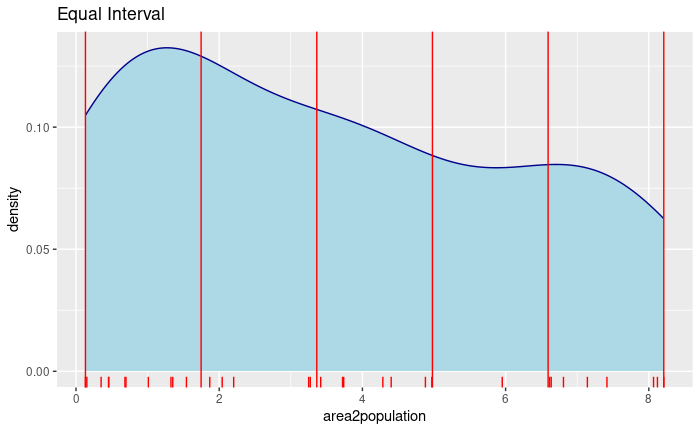

```r
ggplot(osogs_pop_est_lad_merged, aes(x = area2population)) +
  geom_density(color = 'darkblue', fill = 'lightblue') +
  geom_rug(color = 'red') +
  geom_vline(xintercept = ei5$brks, color = 'red') +
  ggtitle('Equal Interval')
```

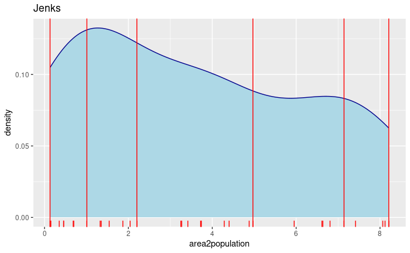

```r
ggplot(osogs_pop_est_lad_merged, aes(x = area2population)) +
  geom_density(color = 'darkblue', fill = 'lightblue') +
  geom_rug(color = 'red') +
  geom_vline(xintercept = fj5$brks, color = 'red') +
  ggtitle('Jenks')
```

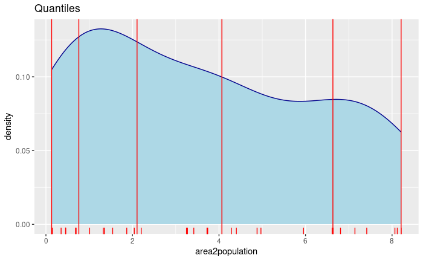

```r
ggplot(osogs_pop_est_lad_merged, aes(x = area2population)) +
  geom_density(color = 'darkblue', fill = 'lightblue') +
  geom_rug(color = 'red') +
  geom_vline(xintercept = q5$brks, color = 'red') +
  ggtitle('Quantiles')
```

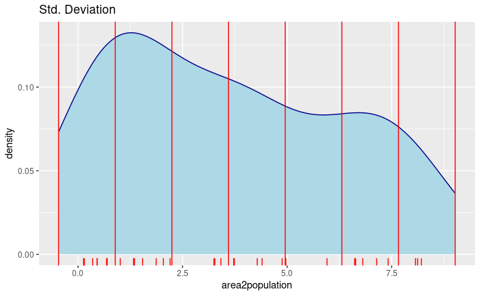

```r
ggplot(osogs_pop_est_lad_merged, aes(x = area2population)) +
  geom_density(color = 'darkblue', fill = 'lightblue') +
  geom_rug(color = 'red') +
  geom_vline(xintercept = msd$brks, color = 'red') +
  ggtitle('Std. Deviation')
```